# One Microservice - Varying Load

Patrick Boehnke

January 3, 2025

# 1 Introduction

In the last post we simulated one microservice and saw a strange behavior. In our high load simulation we saw that requests were taking significantly longer to complete. To understand this behavior, I want to run a bunch of simulations while varying the time between requests.

# 2 A quick recap

Let’s quickly look at the simulation code from last time:

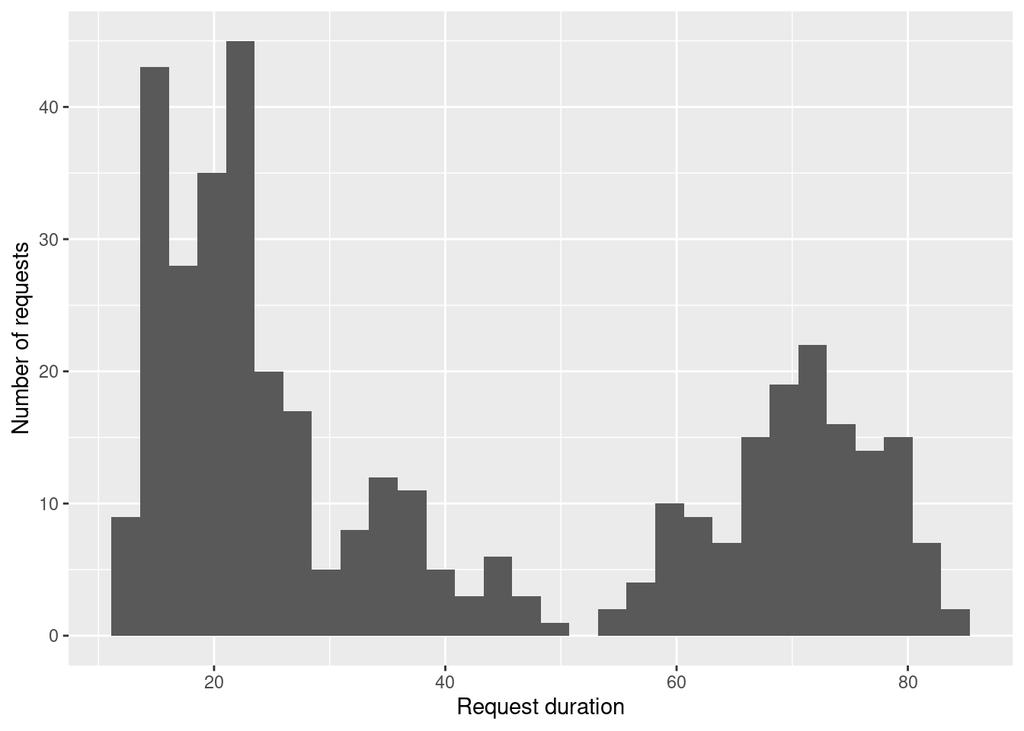

```r
library(simmer)
library(ggplot2)
library(dplyr)
set.seed(42)

env <- simmer("OneMicroService")

request <- trajectory("request path") %>%
  ## add a api hosting app
  seize("app", 1) %>%
  timeout(function() rnorm(1, 10)) %>%
  release("app", 1) %>%
  ## add a backing database
  seize("database", 1) %>%
  timeout(function() rnorm(1, 5)) %>%
  release("database", 1)

env %>%
  add_resource("app", capacity=1, queue_size = 20) %>%
  add_resource("database", capacity=1, queue_size = 20) %>%
  add_generator("request", request, function() rnorm(1, 10, 2))

env %>% run(until = 4000)

env %>%
  get_mon_arrivals %>%
  ggplot(aes(end_time - start_time)) +
  geom_histogram() +
  xlab("Request duration") +
  ylab("Number of requests")
```

From the graph we can see that while most requests finish in the expected amount of time, there are many that take 2-4x longer than they should. Let’s find out how the time between requests influences the slowdown that we see.

# 3 Varying load

To update our simulation to vary the load we’re going to need to wrap our code in a loop and iterate through the arrival time gaps. We’re going to start with one minute of time between requests and increase all the way to 20. To minimize duplicate code, I’m going to first wrap our simulation in a function that takes the arrival time distribution as a variable.

```r
microservice <- function(timedelta){
  env <- simmer("OneMicroService")

  request <- trajectory("request path") %>%
    ## add a api hosting app
    seize("app", 1) %>%
    timeout(function() rnorm(1, 10)) %>%
    release("app", 1) %>%
    ## add a backing database
    seize("database", 1) %>%
    timeout(function() rnorm(1, 5)) %>%
    release("database", 1)

  env %>%
    add_resource("app", capacity=1, queue_size = 20) %>%
    add_resource("database", capacity=1, queue_size = 20) %>%
    add_generator("request", request, function() rnorm(1, timedelta, 0.02))

  env %>% run(until = 4000)

  env %>% get_mon_arrivals %>% mutate(duration = end_time - start_time) -> results
  return(mean(results$duration))
}
```

Now that we have our function written, let’s write a loop to find out how the duration changes as we change the duration between requests.

```r
for(x in 1:20){
  print(microservice(x))
}
```

```
## [1] 20.9179
## [1] 41.85146
## [1] 62.72946
## [1] 83.51513
## [1] 103.6615
## [1] 123.4107
## [1] 140.8581
## [1] 155.907
## [1] 154.8649
## [1] 22.87861
## [1] 15.25033
## [1] 15.00933
## [1] 14.96241
## [1] 15.00253
## [1] 15.05701
## [1] 15.01952
## [1] 14.98188
## [1] 14.88486
## [1] 15.03016
## [1] 15.18703
```